# Homework 4

TJ Schaeffer

2/18/20

```r
# clean up workspace environment
rm(list = ls())

# all packages used for the assignment
library(readr)
library(DataComputing)
library(dplyr)
library(ggplot2)
library(stats)
```

```r
# loading playbill package
playbill <- read.csv("/Users/thomasschaeffer/Sophomore Year/STAT-462/462_HW4/playbill.csv")
```

# Question 1 - What is the response variable?

Current Week

# Question 2

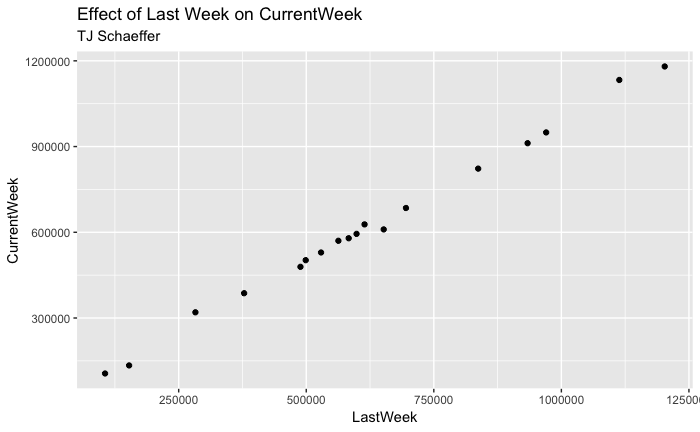

```r
ggplot(data=playbill,aes(x=LastWeek,y=CurrentWeek))+geom_point() + labs(title = "Effect of Last Week on CurrentWeek", subtitle = "TJ Schaeffer")
```

# Question 3 and 4

```r
lm(CurrentWeek ~ LastWeek, data = playbill)
```

```
Call:
lm(formula = CurrentWeek ~ LastWeek, data = playbill)

Coefficients:
(Intercept)     LastWeek
  6804.8860       0.9821
```

# Question 5

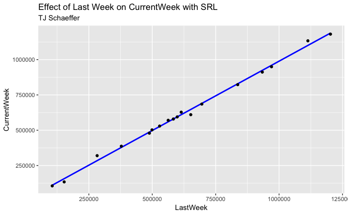

```r
ggplot(data=playbill,aes(x=LastWeek,y=CurrentWeek)) + geom_smooth(method='lm', se = FALSE, color = "blue") + geom_point() + labs(title = "Effect of Last Week on CurrentWeek with SRL", subtitle = "TJ Schaeffer")
```

# Question 6

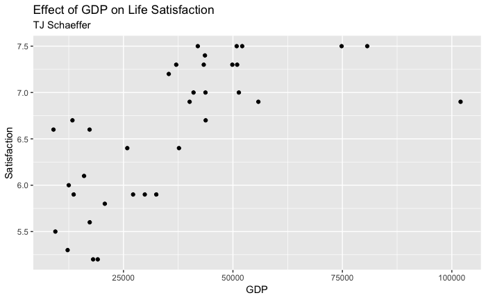

```r
GDPS <- read.csv("/Users/thomasschaeffer/Sophomore Year/STAT-462/462_HW4/GDP_vs_Satisfaction.csv")
ggplot(data=GDPS,aes(x=GDP,y=Satisfaction))+geom_point() + labs(title = "Effect of GDP on Life Satisfaction", subtitle = "TJ Schaeffer")
```

# Question 7

```r
cor.test(GDPS$Satisfaction, GDPS$GDP)
```

```
    Pearson's product-moment correlation

data:  GDPS$Satisfaction and GDPS$GDP
t = 5.4367, df = 33, p-value = 5.083e-06
alternative hypothesis: true correlation is not equal to 0
95 percent confidence interval:
 0.4593531 0.8304061
sample estimates:
      cor
0.6873774
```

# Question 8

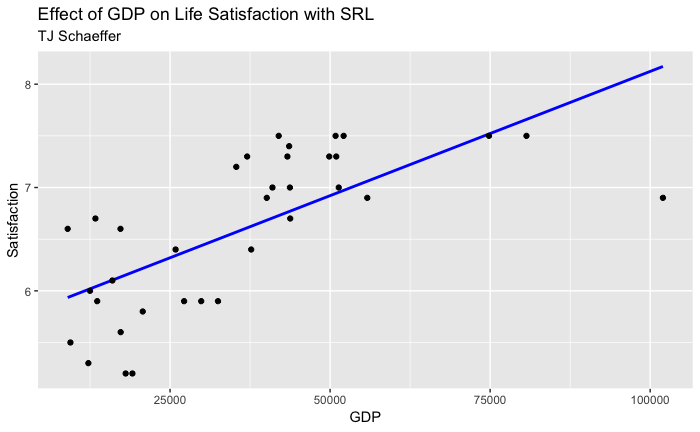

```r
ggplot(data=GDPS,aes(x=GDP,y=Satisfaction)) + geom_smooth(method='lm', se = FALSE, color = "blue") + geom_point() + labs(title = "Effect of GDP on Life Satisfaction with SRL", subtitle = "TJ Schaeffer")
```

# Question 9

```r
GDPSnew <- GDPS[-21, ]
```

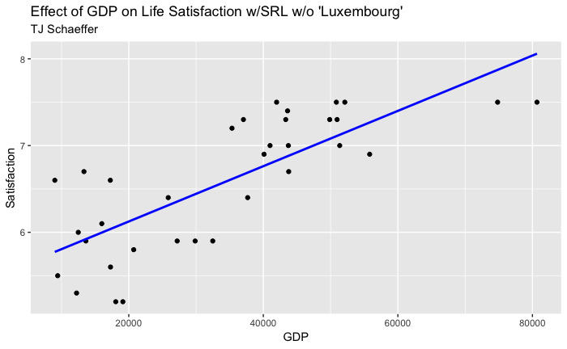

```r
ggplot(data=GDPSnew,aes(x=GDP,y=Satisfaction))+geom_point() + geom_smooth(method = "lm", se = FALSE, color = "blue") + labs(title = "Effect of GDP on Life Satisfaction w/SRL w/o 'Luxembourg'", subtitle = "TJ Schaeffer")
```

# Question 10

After viewing the plot, it does seem like the model fit has improved once “Luxembourg” was removed from the dataset because it increases the correlation between all the points, which is evident in the increase from a .687 correlation to .771 correlation

```r
cor.test(GDPS$Satisfaction, GDPS$GDP)
```

```
    Pearson's product-moment correlation

data:  GDPS$Satisfaction and GDPS$GDP
t = 5.4367, df = 33, p-value = 5.083e-06
alternative hypothesis: true correlation is not equal to 0
95 percent confidence interval:
 0.4593531 0.8304061
sample estimates:
      cor
0.6873774
```

```r
cor.test(GDPSnew$Satisfaction, GDPSnew$GDP)
```

```
    Pearson's product-moment correlation

data:  GDPSnew$Satisfaction and GDPSnew$GDP
t = 6.8447, df = 32, p-value = 9.643e-08
alternative hypothesis: true correlation is not equal to 0
95 percent confidence interval:
 0.5851992 0.8796850
sample estimates:
      cor
0.7708233
```

# Question 11

Salary = 25792.2 + 9450(YearsExperience)

# Question 12

Based on the equation before, we can determine that the average starting salary of all jobs is 25,792.20 dollars and as a worker increases with Years of Experience, the salary increases by 9450 dollars per year.

# Question 13

R^2 = SSReg / SST = 2.0857 X 10^10 / 2.1795 x 10^10 = .957 SST = 2.0857 X 10^10 + 9.3813 X 10^8 = 2.1795 x 10^10 SSReg = 2.0857 X 10^10

Based on the coefficient of determination, 95.7% of the the data in the salarydata is accounted for by the fitted regression line.